# Import packages and data

```python
%%capture
import numpy as np
import pandas as pd
import matplotlib.pyplot as plt
import seaborn as sns
import graphviz

try:
  from prettytable import PrettyTable
  from pypfopt import HRPOpt
except:
  !pip install -q - U prettytable
  !pip install -q -U PyPortfolioOpt
  from pypfopt import HRPOpt
  from prettytable import PrettyTable


from google.colab import drive
from IPython.display import display_html, HTML, display
from statsmodels.tsa.stattools import adfuller
from statsmodels.graphics.tsaplots import plot_acf

from sklearn.preprocessing import StandardScaler
from sklearn.decomposition import PCA
from sklearn.model_selection import train_test_split
from sklearn.linear_model import LogisticRegression
from sklearn.svm import SVC
from sklearn.ensemble import RandomForestClassifier
from sklearn import metrics

from sklearn.tree import export_graphviz
from IPython.display import Image
from scipy import stats
from statistics import multimode
from scipy.cluster import hierarchy
from scipy.cluster.hierarchy import linkage, dendrogram
from scipy.spatial.distance import squareform
from pypfopt import plotting
```

```python
# get all data from GitHub repo
files = ['er','ed','futures','infswp','sofr','yields','ez_cds']
file_dict = {}

for file in files:
  file_dict[file] = pd.read_csv('https://raw.githubusercontent.com/sjv1030/wq-capstone/main/data/'+file+'.csv')
  file_dict[file]['Date'] = pd.to_datetime(file_dict[file]['Date'], format='%m/%d/%Y')
  file_dict[file].set_index('Date', inplace=True)
  file_dict[file] = file_dict[file].loc[:'2024-02'].copy()
  file_dict[file].columns = file_dict[file].columns.str.strip()
  #print(file_dict[file].info())
  #display(file_dict[file].head())
```

# Data transformation

```python
# Initial training period (year)
beg_yr = 2010
end_yr = 2012
```

## Convert STIR into yield term

Cycle through all contracts and get difference between Eurodollar futures and SOFR futures. For each contract, identify the date where the absolute delta between the Eurodollar and SOFR contract prices is minimized. This date will be used to merge the two contracts in the next step.

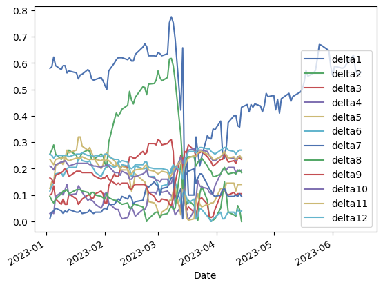

```python
merge_ed_sfr = dict()
for k in range(1,13):
  _ = pd.concat([file_dict['ed'][['ED'+str(k)]], file_dict['sofr'][['SFR'+str(k)]]], axis=1)
  _['delta'+str(k)] = np.abs(_['ED'+str(k)] - _['SFR'+str(k)])
  _['delta'+str(k)].loc['2023':'2023'].dropna().plot(legend=True)
  dates = (_['delta'+str(k)].loc['2023':'2023'].index[_['delta'+str(k)].loc['2023':'2023'].dropna().argmin()],
           _['delta'+str(k)].loc['2023':'2023'].index[_['delta'+str(k)].loc['2023':'2023'].dropna().argmin()+1])
  merge_ed_sfr[k] = dates

plt.show()
```

```python
# merge ED and SFR futures
backdated_SFR = pd.DataFrame()
for k in range(1,13):
  merge_date, merge_date_1 = merge_ed_sfr[k]
  tmp = pd.concat([file_dict['ed']['ED'+str(k)].loc[:merge_date],
                    file_dict['sofr']['SFR'+str(k)].loc[merge_date_1:]], axis=0
  )
  backdated_SFR['SFR'+str(k)] = tmp
```

Calculate calendar spreads for the STIR futures. The result is in yield terms.

Short-term interest rate (STIR) futures are quoted in price terms. Given standard contract conventions, 100 less the price equates to a yield in percent form. Arguably, for macro/fixed-income investment ideas, the yield is more important.

Note that a term spread is usually calculated with the longer duration security first.

For example, the US Yield Curve can be defind as 10-year US Treasury less the 2-year US Treasury But with STIR futures, one can reverse the order to get the term spread in yield terms.

Example - Using prices from Jan 9, 2023:

- SFR4's price was 95.405 (or 4.595%)
- SFR8's price was 96.790 (or 3.21%)

One can calculate the term spread as SFR4 - SFR8, or -1.385% Note: the term spread is negative because the curve is inverted

```python
# calculate STIR calendar spreads
tmp_dict = {}
for i in range(1,12):
  for j in range(2,13):
    if i < j:
      tmp_dict['ER'+str(i)+'-'+str(j)] = file_dict['er']['ER'+str(i)] - file_dict['er']['ER'+str(j)]
      tmp_dict['SFR'+str(i)+'-'+str(j)] = backdated_SFR['SFR'+str(i)] - backdated_SFR['SFR'+str(j)]

# save data to a dataframe
full_data = pd.DataFrame.from_dict(tmp_dict)
```

```python
# calculate cross country spreads at key tenors and add to main dataframe
tmp_dict = {}
for i in range(4,13,2):
  tmp_dict['SFRER'+str(i)] = backdated_SFR['SFR'+str(i)] - file_dict['er']['ER'+str(i)]

full_data = full_data.join(pd.DataFrame.from_dict(tmp_dict), how='left')
```

## Create spreads

Below is a large dictionary holding all of the various spreads to be used as either a target or within the feature set.

```python
file_dict['spread'] = pd.DataFrame()

file_dict['spread']['US302'] = file_dict['yields']['US30'] - file_dict['yields']['US2']
file_dict['spread']['US305'] = file_dict['yields']['US30'] - file_dict['yields']['US5']
file_dict['spread']['US3010'] = file_dict['yields']['US30'] - file_dict['yields']['US10']
file_dict['spread']['US102'] = file_dict['yields']['US10'] - file_dict['yields']['US2']
file_dict['spread']['US105'] = file_dict['yields']['US10'] - file_dict['yields']['US5']
file_dict['spread']['US52'] = file_dict['yields']['US5'] - file_dict['yields']['US2']

file_dict['spread']['DE302'] = file_dict['yields']['DE30'] - file_dict['yields']['DE2']
file_dict['spread']['DE305'] = file_dict['yields']['DE30'] - file_dict['yields']['DE5']
file_dict['spread']['DE3010'] = file_dict['yields']['DE30'] - file_dict['yields']['DE10']
file_dict['spread']['DE102'] = file_dict['yields']['DE10'] - file_dict['yields']['DE2']
file_dict['spread']['DE105'] = file_dict['yields']['DE10'] - file_dict['yields']['DE5']
file_dict['spread']['DE52'] = file_dict['yields']['DE5'] - file_dict['yields']['DE2']

file_dict['spread']['CA102'] = file_dict['yields']['CA10'] - file_dict['yields']['CA2']
file_dict['spread']['CA105'] = file_dict['yields']['CA10'] - file_dict['yields']['CA5']
file_dict['spread']['CA52'] = file_dict['yields']['CA5'] - file_dict['yields']['CA2']

file_dict['spread']['ITDE10'] = file_dict['yields']['IT10'] - file_dict['yields']['DE10']
file_dict['spread']['USDE2'] = file_dict['yields']['US2'] - file_dict['yields']['DE2']
file_dict['spread']['USDE5'] = file_dict['yields']['US5'] - file_dict['yields']['DE5']
file_dict['spread']['USDE10'] = file_dict['yields']['US10'] - file_dict['yields']['DE10']

file_dict['spread']['USEZINF2'] = file_dict['infswp']['US-2'] - file_dict['infswp']['EZ-2']
file_dict['spread']['USEZINF5'] = file_dict['infswp']['US-5'] - file_dict['infswp']['EZ-5']
file_dict['spread']['USEZINF10'] = file_dict['infswp']['US-10'] - file_dict['infswp']['EZ-10']

file_dict['spread']['USINF102'] = file_dict['infswp']['US-10'] - file_dict['infswp']['US-2']
file_dict['spread']['USINF105'] = file_dict['infswp']['US-10'] - file_dict['infswp']['US-5']
file_dict['spread']['USINF52'] = file_dict['infswp']['US-5'] - file_dict['infswp']['US-2']

file_dict['spread']['EZINF102'] = file_dict['infswp']['EZ-10'] - file_dict['infswp']['EZ-2']
file_dict['spread']['EZINF105'] = file_dict['infswp']['EZ-10'] - file_dict['infswp']['EZ-5']
file_dict['spread']['EZINF52'] = file_dict['infswp']['EZ-5'] - file_dict['infswp']['EZ-2']
```

```python
# STIR futures strictly follow US trading days, so the other dataframe holding spreads (calculated above) will be merged with this one
full_data = full_data.join(file_dict['spread'], how='left')
full_data = full_data.join(file_dict['yields'], how='left')
full_data = full_data.join(file_dict['infswp'], how='left')
full_data.head()
```

| Date | ER1-2 | SFR1-2 | ER1-3 | SFR1-3 | ER1-4 | SFR1-4 | ER1-5 | SFR1-5 | ER1-6 | SFR1-6 | ... | US10 | US2 | US5 | US30 | EZ-2 | EZ-5 | EZ-10 | US-2 | US-5 | US-10 |
| --- | --- | --- | --- | --- | --- | --- | --- | --- | --- | --- | --- | --- | --- | --- | --- | --- | --- | --- | --- | --- | --- |
| 2010-01-04 | 0.360 | 0.280 | 0.73 | 0.660 | 1.065 | 1.075 | 1.330 | 1.475 | 1.570 | 1.865 | ... | 3.8155 | 1.0638 | 2.6350 | 4.6431 | 1.6800 | 2.1600 | 2.4410 | 1.5398 | 2.3475 | 2.7818 |
| 2010-01-05 | 0.335 | 0.245 | 0.70 | 0.610 | 1.025 | 1.005 | 1.295 | 1.385 | 1.540 | 1.760 | ... | 3.7608 | 1.0080 | 2.5611 | 4.6091 | 1.7025 | 2.1725 | 2.4575 | 1.5556 | 2.3500 | 2.7937 |
| 2010-01-06 | 0.330 | 0.225 | 0.69 | 0.585 | 1.015 | 0.990 | 1.290 | 1.385 | 1.545 | 1.770 | ... | 3.8215 | 0.9920 | 2.5913 | 4.6875 | 1.7300 | 2.1950 | 2.4880 | 1.5811 | 2.4050 | 2.8445 |
| 2010-01-07 | 0.310 | 0.225 | 0.66 | 0.590 | 0.985 | 1.005 | 1.260 | 1.415 | 1.525 | 1.810 | ... | 3.8235 | 1.0240 | 2.6115 | 4.6855 | 1.7650 | 2.2200 | 2.4880 | 1.6155 | 2.3545 | 2.8551 |
| 2010-01-08 | 0.300 | 0.190 | 0.64 | 0.520 | 0.955 | 0.925 | 1.230 | 1.330 | 1.500 | 1.735 | ... | 3.8297 | 0.9759 | 2.5912 | 4.7150 | 1.7600 | 2.2050 | 2.4670 | 1.6061 | 2.3920 | 2.8490 |

5 rows × 184 columns

## PCA for EZ CDS

```python
# this function will be leveraged in the work-forward analysis
# to test the Italian-German 10-year spread

def make_pca(df, beg, end):
  '''
  Function creates a risk index from PCA loadings.
  '''
  cds = df.fillna(method='ffill').iloc[beg:end].diff().dropna().values
  scaler = StandardScaler()
  scaled_cds = scaler.fit_transform(cds)

  pca = PCA(n_components=3)

  pc = pca.fit_transform(scaled_cds)

  # multiply PCA loadings with scaled underlying data
  scaled_cds_array = np.array(scaled_cds)
  scaled_loadings = np.dot(scaled_cds_array, pca.components_.T)

  # multiply "scaled loadings" with principal component weights, respectively
  # to create one index that combines all three principal components
  # this index had to be negated to make it comparable with underlying CDS data

  EZ_risk_index = -np.dot(scaled_loadings, pca.explained_variance_)
  EZ_risk = pd.DataFrame(EZ_risk_index.cumsum(), index=file_dict['ez_cds'].loc[str(beg):str(end)].index[1:])
  EZ_risk.columns = ['EZ Risk Index']
  return EZ_risk
```

Use PCA to identify the top principal components (PCs). Plot a chart of explained variance and a biplot showing how the original data maps onto the first 2 PCs.

```
[0.81588054 0.05860003 0.04874604]
[0.81588054 0.87448057 0.92322662]
```

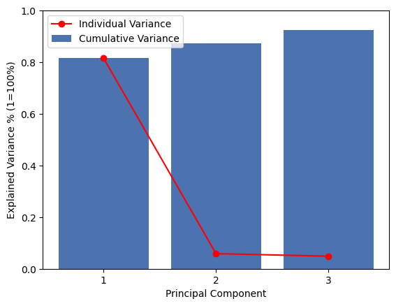

```python
cds = file_dict['ez_cds'].fillna(method='ffill').loc[str(beg_yr):str(end_yr)].diff().dropna().values
scaler = StandardScaler()
scaled_cds = scaler.fit_transform(cds)

pca = PCA(n_components=3)

pc = pca.fit_transform(scaled_cds)

print(pca.explained_variance_ratio_)
print(pca.explained_variance_ratio_.cumsum())

plt.bar([1,2,3], pca.explained_variance_ratio_.cumsum())
plt.plot([1,2,3], pca.explained_variance_ratio_, color='red', marker='o')
plt.legend(['Individual Variance', 'Cumulative Variance'])
plt.xlabel('Principal Component')
plt.ylabel('Explained Variance % (1=100%)')
plt.ylim([0,1])
plt.xticks(np.arange(1, 3.1, step=1))
plt.show()
```

|  | PC1 | PC2 | PC3 |
| --- | --- | --- | --- |
| CS | -0.341493 | 0.319370 | 0.515410 |
| UBS | -0.339588 | 0.367801 | 0.469703 |
| Unicredit | -0.362522 | -0.041834 | -0.334119 |
| BancoSantander | -0.353965 | -0.544182 | 0.199138 |
| BNP | -0.360829 | 0.245916 | -0.315533 |
| Intesa | -0.360868 | -0.045345 | -0.394348 |
| SocGen | -0.356120 | 0.284210 | -0.267641 |
| BBVA | -0.352283 | -0.567040 | 0.189044 |

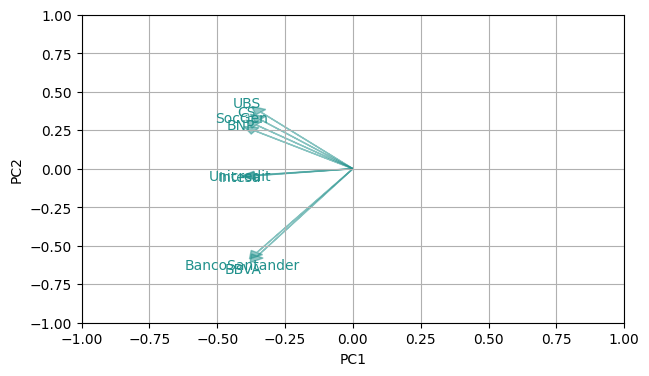

```python
# visualize the loadings
loadings = pd.DataFrame(pca.components_.T, columns=['PC1', 'PC2', 'PC3'], index=file_dict['ez_cds'].columns)
display(loadings)

def loading_plot(coeff, labels):
    n = coeff.shape[0]
    for i in range(n):
        plt.arrow(0, 0, coeff[i,0], coeff[i,1], head_width = 0.05, head_length = 0.05, color = '#21918C',alpha = 0.5)
        plt.text(coeff[i,0]* 1.15, coeff[i,1] * 1.15, labels[i], color = '#21918C', ha = 'center', va = 'center')
    plt.xlim(-1,1)
    plt.ylim(-1,1)
    plt.xlabel('PC1')
    plt.ylabel('PC2')
    plt.grid()

fig, ax = plt.subplots(figsize = (7,4))
loading_plot(pca.components_.T, file_dict['ez_cds'].columns)
plt.show()
```

```python
# multiply PCA loadings with scaled underlying data
scaled_cds_array = np.array(scaled_cds)
scaled_loadings = np.dot(scaled_cds_array, pca.components_.T)

# multiply "scaled loadings" with principal component weights, respectively
# to create one index that combines all three principal components
# this index had to be negated to make it comparable with underlying CDS data

EZ_risk_index = -np.dot(scaled_loadings, pca.explained_variance_)
```

The risk index created using the PCA loadings and scaled CDS data aligns well with the underlying CDS data, suggesting it is capturing a large amount of the common variation.

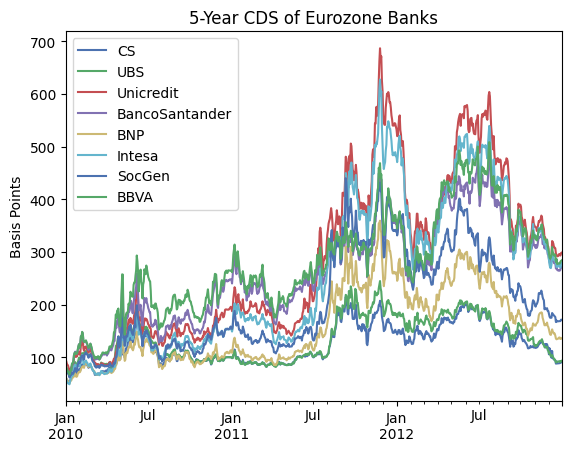

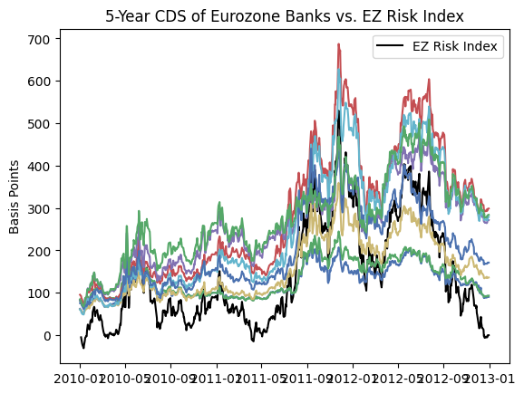

```python
file_dict['ez_cds'].loc[str(beg_yr):str(end_yr)].plot(legend=True)
plt.title('5-Year CDS of Eurozone Banks')
plt.xlabel('')
plt.ylabel('Basis Points')
plt.show()

plt.plot(file_dict['ez_cds'].loc[str(beg_yr):str(end_yr)].index[1:], EZ_risk_index.cumsum(),
         label='EZ Risk Index', color='k')
plt.title('5-Year CDS of Eurozone Banks vs. EZ Risk Index')
plt.ylabel('Basis Points')
plt.legend()
plt.plot(file_dict['ez_cds'].loc[str(beg_yr):str(end_yr)])
plt.show()
```

```python
# create PCA index and add to larger datafile
EZ_risk = pd.DataFrame(EZ_risk_index.cumsum(), index=file_dict['ez_cds'].loc[str(beg_yr):str(end_yr)].index[1:])
EZ_risk.columns = ['EZ Risk Index']

full_data = full_data.join(EZ_risk, how='left')
full_data.head()
```

| Date | ER1-2 | SFR1-2 | ER1-3 | SFR1-3 | ER1-4 | SFR1-4 | ER1-5 | SFR1-5 | ER1-6 | SFR1-6 | ... | US2 | US5 | US30 | EZ-2 | EZ-5 | EZ-10 | US-2 | US-5 | US-10 | EZ Risk Index |
| --- | --- | --- | --- | --- | --- | --- | --- | --- | --- | --- | --- | --- | --- | --- | --- | --- | --- | --- | --- | --- | --- |
| 2010-01-04 | 0.360 | 0.280 | 0.73 | 0.660 | 1.065 | 1.075 | 1.330 | 1.475 | 1.570 | 1.865 | ... | 1.0638 | 2.6350 | 4.6431 | 1.6800 | 2.1600 | 2.4410 | 1.5398 | 2.3475 | 2.7818 | -4.918199 |
| 2010-01-05 | 0.335 | 0.245 | 0.70 | 0.610 | 1.025 | 1.005 | 1.295 | 1.385 | 1.540 | 1.760 | ... | 1.0080 | 2.5611 | 4.6091 | 1.7025 | 2.1725 | 2.4575 | 1.5556 | 2.3500 | 2.7937 | -10.947791 |
| 2010-01-06 | 0.330 | 0.225 | 0.69 | 0.585 | 1.015 | 0.990 | 1.290 | 1.385 | 1.545 | 1.770 | ... | 0.9920 | 2.5913 | 4.6875 | 1.7300 | 2.1950 | 2.4880 | 1.5811 | 2.4050 | 2.8445 | -15.339995 |
| 2010-01-07 | 0.310 | 0.225 | 0.66 | 0.590 | 0.985 | 1.005 | 1.260 | 1.415 | 1.525 | 1.810 | ... | 1.0240 | 2.6115 | 4.6855 | 1.7650 | 2.2200 | 2.4880 | 1.6155 | 2.3545 | 2.8551 | -20.284589 |
| 2010-01-08 | 0.300 | 0.190 | 0.64 | 0.520 | 0.955 | 0.925 | 1.230 | 1.330 | 1.500 | 1.735 | ... | 0.9759 | 2.5912 | 4.7150 | 1.7600 | 2.2050 | 2.4670 | 1.6061 | 2.3920 | 2.8490 | -23.648763 |

5 rows × 185 columns

# EDA

```python
# convert dataset to weekly at Friday observations
full_data_wf = full_data.resample('W-FRI').last()
full_data_wf.head()
```

| Date | ER1-2 | SFR1-2 | ER1-3 | SFR1-3 | ER1-4 | SFR1-4 | ER1-5 | SFR1-5 | ER1-6 | SFR1-6 | ... | US2 | US5 | US30 | EZ-2 | EZ-5 | EZ-10 | US-2 | US-5 | US-10 | EZ Risk Index |
| --- | --- | --- | --- | --- | --- | --- | --- | --- | --- | --- | --- | --- | --- | --- | --- | --- | --- | --- | --- | --- | --- |
| 2010-01-08 | 0.300 | 0.190 | 0.640 | 0.520 | 0.955 | 0.925 | 1.230 | 1.330 | 1.500 | 1.735 | ... | 0.9759 | 2.5912 | 4.7150 | 1.7600 | 2.2050 | 2.4670 | 1.6061 | 2.3920 | 2.8490 | -23.648763 |
| 2010-01-15 | 0.255 | 0.135 | 0.555 | 0.425 | 0.835 | 0.800 | 1.080 | 1.185 | 1.335 | 1.560 | ... | 0.8621 | 2.4159 | 4.5814 | 1.7000 | 2.1030 | 2.3680 | 1.5670 | 2.2750 | 2.7300 | -6.161920 |
| 2010-01-22 | 0.225 | 0.110 | 0.500 | 0.370 | 0.780 | 0.730 | 1.035 | 1.100 | 1.285 | 1.470 | ... | 0.7875 | 2.3414 | 4.5312 | 1.6995 | 2.0470 | 2.3110 | 1.5878 | 2.2090 | 2.6706 | 25.244170 |
| 2010-01-29 | 0.265 | 0.115 | 0.550 | 0.355 | 0.820 | 0.700 | 1.060 | 1.080 | 1.290 | 1.460 | ... | 0.8118 | 2.3232 | 4.4884 | 1.5100 | 1.8950 | 2.2982 | 1.5722 | 2.2440 | 2.7591 | 33.599325 |
| 2010-02-05 | 0.235 | 0.105 | 0.445 | 0.305 | 0.660 | 0.610 | 0.860 | 0.950 | 1.070 | 1.300 | ... | 0.7633 | 2.2333 | 4.5186 | 1.4375 | 1.8125 | 2.1925 | 1.4932 | 2.1355 | 2.6228 | 57.463195 |

5 rows × 185 columns

## Correlations

Intuitively, the various permutations of spreads calculated for the STIR futures above will have a high level of correlation amongst themselves.

As a result, the correlation heatmaps below focused on the yield spreads.

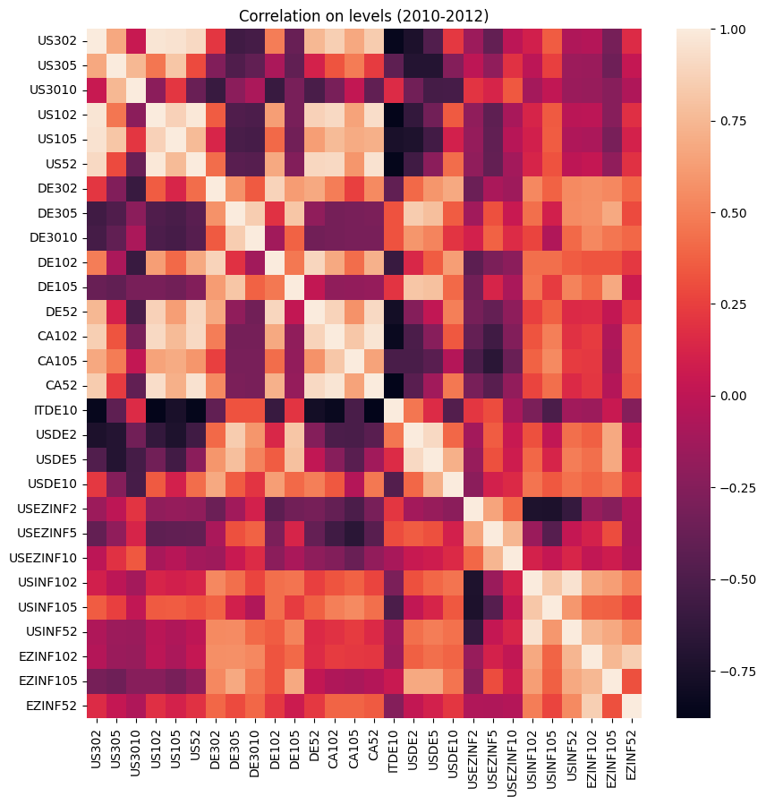

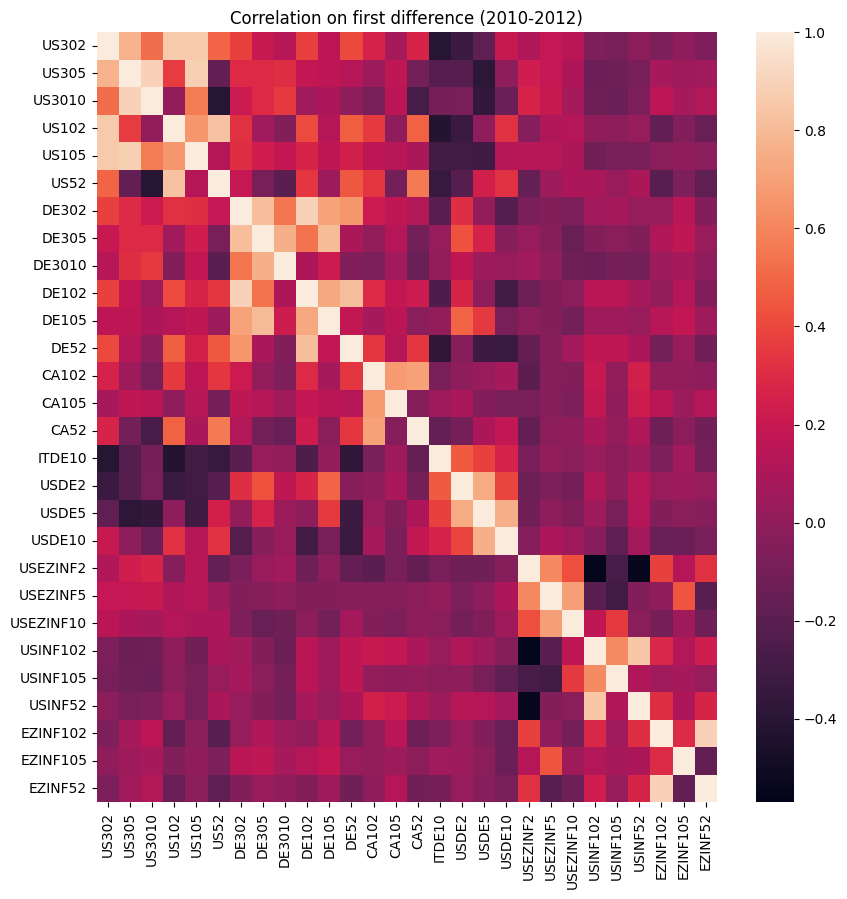

```python
spreads_cols = file_dict['spread'].columns
fig, ax = plt.subplots(figsize=(10,10))
sns.heatmap(full_data_wf[spreads_cols].loc[str(beg_yr):str(end_yr)].corr(method='pearson').round(2))
plt.title('Correlation on levels ('+str(beg_yr)+'-'+str(end_yr)+')')
plt.show()

fig, ax = plt.subplots(figsize=(10,10))
sns.heatmap(full_data_wf[spreads_cols].loc[str(beg_yr):str(end_yr)].diff().corr(method='pearson').round(2))
plt.title('Correlation on first difference ('+str(beg_yr)+'-'+str(end_yr)+')')
plt.show()
```

### Feature Selection via Correlations

The absolute value of pearson correlation is used to select the top securities whose values are above 0.7 (with a maximum of 10 features per target variable). This process will occur every time the model is updated during the walk-forward backtest.

```python
target_list = []
for col in full_data_wf.columns:
  if col in file_dict['ed'].columns:
    continue
  elif col in file_dict['sofr'].columns:
    continue
  elif col in file_dict['yields'].columns:
    continue
  elif col in file_dict['ez_cds'].columns:
    continue
  elif col in file_dict['infswp'].columns:
    continue
  elif col == 'EZ Risk Index':
    continue
  else:
     target_list.append(col)
```

```python
#target_list = ['US102','DE52','USDE10','SFR4-8','SFR6-12','ER4-8','ER6-12','USDE5',
#               'SFR2-8','ER2-8','ITDE10']

#target_list = spreads_cols.copy()
feature_dict = dict()
for tgt in target_list:
  _corr = full_data_wf.loc[str(beg_yr):str(end_yr)].diff().corr(method='pearson')[tgt]
  feature_dict[tgt] = _corr.abs().sort_values(ascending=False).where(lambda x: x > 0.7).dropna().index.tolist()[1:11]
```

The table below shows the target as column headings and the features (in the rows) that have the highest correlation (either positive or negative).

```python
#feat_df = pd.DataFrame.from_dict(feature_list)
feat_df = pd.DataFrame(dict([ (k,pd.Series(v)) for k,v in feature_dict.items() ]))
display(HTML(feat_df[spreads_cols].to_html()))
```

|  | US302 | US305 | US3010 | US102 | US105 | US52 | DE302 | DE305 | DE3010 | DE102 | DE105 | DE52 | CA102 | CA105 | CA52 | ITDE10 | USDE2 | USDE5 | USDE10 | USEZINF2 | USEZINF5 | USEZINF10 | USINF102 | USINF105 | USINF52 | EZINF102 | EZINF105 | EZINF52 |
| --- | --- | --- | --- | --- | --- | --- | --- | --- | --- | --- | --- | --- | --- | --- | --- | --- | --- | --- | --- | --- | --- | --- | --- | --- | --- | --- | --- | --- |
| 0 | US30 | US3010 | US305 | US10 | US305 | US5 | DE102 | DE302 | DE305 | DE302 | DE305 | DE102 | CA52 | NaN | CA102 | IT10 | SFRER4 | SFRER8 | USDE5 | US-2 | NaN | NaN | USINF52 | NaN | USINF102 | EZINF52 | NaN | EZINF102 |
| 1 | US105 | US105 | NaN | US30 | US302 | US10 | DE305 | DE105 | NaN | DE52 | DE102 | NaN | NaN | NaN | NaN | NaN | DE2 | SFRER10 | NaN | NaN | NaN | NaN | US-2 | NaN | US-2 | EZ-2 | NaN | NaN |
| 2 | US102 | US302 | NaN | US302 | NaN | SFR2-12 | DE105 | DE3010 | NaN | DE105 | DE302 | NaN | NaN | NaN | NaN | NaN | SFRER6 | USDE10 | NaN | NaN | NaN | NaN | NaN | NaN | NaN | NaN | NaN | NaN |
| 3 | US305 | NaN | NaN | US52 | NaN | SFR1-12 | NaN | NaN | NaN | NaN | NaN | NaN | NaN | NaN | NaN | NaN | USDE5 | SFRER6 | NaN | NaN | NaN | NaN | NaN | NaN | NaN | NaN | NaN | NaN |
| 4 | NaN | NaN | NaN | UK10 | NaN | SFR4-12 | NaN | NaN | NaN | NaN | NaN | NaN | NaN | NaN | NaN | NaN | DE5 | USDE2 | NaN | NaN | NaN | NaN | NaN | NaN | NaN | NaN | NaN | NaN |
| 5 | NaN | NaN | NaN | SFR8-12 | NaN | SFR3-12 | NaN | NaN | NaN | NaN | NaN | NaN | NaN | NaN | NaN | NaN | NaN | SFRER12 | NaN | NaN | NaN | NaN | NaN | NaN | NaN | NaN | NaN | NaN |
| 6 | NaN | NaN | NaN | SFR7-12 | NaN | SFR5-12 | NaN | NaN | NaN | NaN | NaN | NaN | NaN | NaN | NaN | NaN | NaN | NaN | NaN | NaN | NaN | NaN | NaN | NaN | NaN | NaN | NaN | NaN |
| 7 | NaN | NaN | NaN | SFR9-12 | NaN | SFR4-11 | NaN | NaN | NaN | NaN | NaN | NaN | NaN | NaN | NaN | NaN | NaN | NaN | NaN | NaN | NaN | NaN | NaN | NaN | NaN | NaN | NaN | NaN |
| 8 | NaN | NaN | NaN | SFR6-12 | NaN | US102 | NaN | NaN | NaN | NaN | NaN | NaN | NaN | NaN | NaN | NaN | NaN | NaN | NaN | NaN | NaN | NaN | NaN | NaN | NaN | NaN | NaN | NaN |
| 9 | NaN | NaN | NaN | NaN | NaN | SFR5-11 | NaN | NaN | NaN | NaN | NaN | NaN | NaN | NaN | NaN | NaN | NaN | NaN | NaN | NaN | NaN | NaN | NaN | NaN | NaN | NaN | NaN | NaN |

## Dendrogram

Hierarchical clustering is used to group stocks that have higher correlations. This approach measures the "distance" between values, which is defined as the distance between correlation coefficients. The farther the distance, then the more different (or dissimilar) the two values are from each other.

The dendrogram below has clustered the stocks based on this distance measure. The x-axis labels are the sorted columns from the correlation matrix.

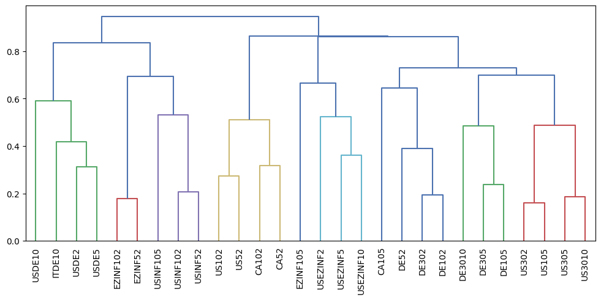

```python
tgt_corr = full_data_wf[spreads_cols].loc[str(beg_yr):str(end_yr)].diff().corr(method='pearson').round(2).corr()
fig, ax = plt.subplots(figsize=(12, 5))
distance = np.sqrt(0.5 * (1 - tgt_corr))
Z = linkage(squareform(distance), 'complete')

dendrogram(Z, labels=tgt_corr.columns, orientation='top', leaf_rotation=90)
x_lab = ax.get_xticklabels()
plt.show()
```

## Plots of raw data

Given the high number of features, only some will be charted for illustration.

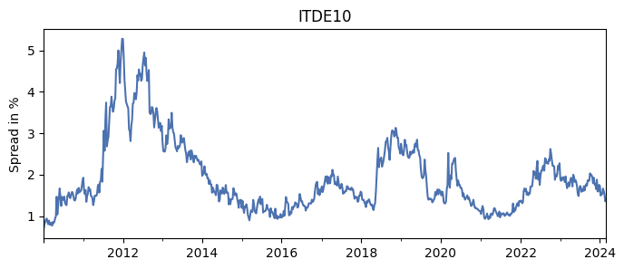

```python
# Plot example of elevated term spread during periods of high macro risk
# like the Italian-German 10-year spread during the Eurozone debt crisis in 2011
plt.figure(figsize=(8,3))
full_data_wf['ITDE10'].plot(title='ITDE10')
plt.ylabel('Spread in %')
plt.xlabel('')
plt.show()
```

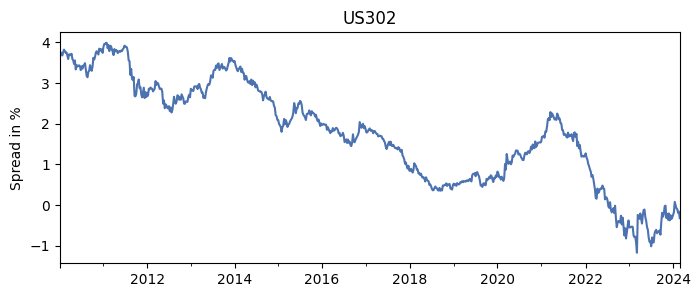

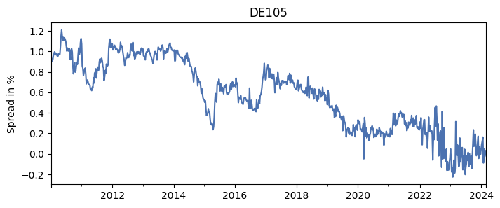

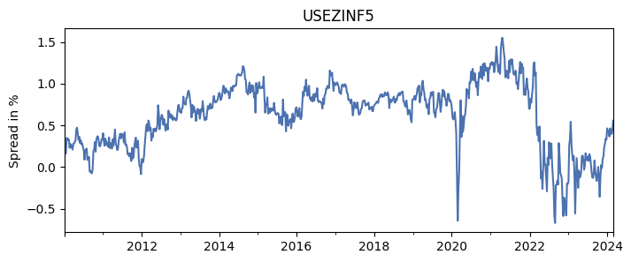

```python
for c, col in enumerate(spreads_cols):
    if c % 10 == 0:
      plt.figure(figsize=(8,3))
      full_data_wf[col].plot(title=col)
      plt.ylabel('Spread in %')
      plt.xlabel('')
      plt.show()
#for c, col in enumerate(full_data_wf.drop(spreads_cols, axis=1).columns):
#    if c % 15 == 0:
#      plt.figure(figsize=(8,3))
#      full_data_wf[col].plot(title=col)
#      plt.ylabel('Spread in %')
#      plt.xlabel('')
#      plt.show()
```

## Check for stationarity

```python
def adf_test(x):
    dftest = adfuller(x.dropna(),autolag='AIC')
    dfoutput = pd.Series(dftest[0:4], index=['Test Statistic','p-value','#Lags Used','Numer of Observations Used'])
    print(dfoutput.round(3))

def run_eda(df):
  for col in df.columns:
    fig, axes = plt.subplots(nrows=1, ncols=3, figsize=(12,3))

    df[col].plot(title=col, ax=axes[0])
    sns.histplot(ax=axes[1], data=df,x=col)
    axes[1].set_title('Distribution')
    plot_acf(df[col].dropna(), ax=axes[2])
    axes[2].set_title('Autocorrelation')
    plt.tight_layout()

  for col in df.columns:
    print('Running ADF on '+col+'\n')
    adf_test(df[col])
    print('----------------------------------------')
```

Run ADF on all the target variables. While the target does not need to be stationary (since it will be converted to a categorical variable), the ADF will help inform if lags of the target should be included in the feature dataset.

The results suggest all target variables have serial correlation and are not stationary.

```python
for tgt in target_list:
  run_eda(full_data_wf[[tgt]].loc[str(beg_yr) : str(end_yr)].diff()[1:])
```

```
Output hidden; open in https://colab.research.google.com to view.
```

# Model Selection & Backtest

Test various classification models (i.e., SVC, Logit, Random Forest) to see which model best predicts an up or down move in a position in a walk-forward analysis.

```python
DV01 = 10000
aum = 1000000
look_back = 3

beg = 0
end = beg+(52*look_back)

# capture positions for each trade to be used in portfolio construction later
position_dict = dict()
```

```python
def get_features (df, beg, end, target):
  '''
  Function takes a pandas dataframe and calculates a correlation matrix
  Using the absolute value of the correlation coefficient, the matrix is sorted
  and filtered to only show correlations above 0.7 up to maximum of 10 relationships.

  Returns the names of the securities with high correlations.
  '''
  _corr = df.iloc[beg:end].diff().corr(method='pearson')[target].abs()
  _feats = _corr.abs().sort_values(by=target, ascending=False).where(lambda x: x > 0.7).dropna().index.tolist()[1:11]
  return _feats

def lag_feature(df, features, target):
  '''
  Function takes a pandas dataframe and inserts lags of all columns.
  Returns a dataframe with all lags inserted, first differenced,
  and a target series as a categorical variable.
  '''
  df = df[features + target].fillna(method='ffill').copy()
  tmp_dict = dict()
  for col in df.columns:
    for l in range(1,5):
      tmp_col = df[col].shift(l).copy()
      tmp_dict[col+'L'+str(l)] = tmp_col
  df = pd.concat([df,
                 pd.DataFrame.from_dict(tmp_dict)],
                 axis=1
  )
  df[target] = df[target].shift(-1)
  df.dropna(inplace=True)

  X = df.diff()[1:].fillna(method='ffill').drop(target, axis=1)
  y = df[target].diff()[1:].fillna(method='ffill')

  upper = 0.03 # +0.03% or up 3 basis points
  lower = -0.03 # -0.03% or down 3 basis points
  y = pd.DataFrame(np.where(y > upper, 1, np.where(y < lower, -1, 0)))
  return X, y



def filter(X, y, beg, end):
  '''
  Function takes the target and features, as well as
  beginning and ending index values as integers.

  Returns target and features over selected time period.
  '''
  X = X.iloc[beg : end].copy()
  y = pd.DataFrame(y).iloc[beg : end].values
  return X, y

def train_logit(X, y):
  '''
  Function takes a feature dataframe and target series,
  and returns a logistic regression model.
  '''
  log = LogisticRegression(solver='saga', multi_class='multinomial')
  log.fit(X, np.reshape(y,-1))
  return log

def valid_logit(X, y, model):
  '''
  Function takes a feature dataframe, target series, and logistic regression
  model, and returns the model score.
  '''
  y_pred = model.predict(X)
  score = model.score(X, y)
  return score

def train_valid_rfc(train_X, train_y, valid_X, valid_y):
  '''
  Function takes a feature dataframe and target series for both the training
  period and validation period.

  A Random Forest Classifier model is trained with some hyperparameter tuning.
  The best model is chosen with the highest F1 score using the validation data.

  The function returns the best model, score, and number of estimators.
  '''
  best_n = 0
  best_score = 0
  for i in range(100, 300, 50):
    rfc = RandomForestClassifier(random_state=51, n_estimators=i)
    rfc.fit(train_X, np.reshape(train_y,-1))
    y_pred = rfc.predict(valid_X)
    tmpf1 = metrics.f1_score(valid_y, y_pred, average='weighted')
    if tmpf1 > best_score:
      best_score = tmpf1
      best_n = i
      best_model = rfc
  return best_model, best_score, best_n

def train_valid_svc(train_X, train_y, valid_X, valid_y):
  '''
  Function takes a feature dataframe and target series for both the training
  period and validation period.

  A Support Vector Classification model is trained with some hyperparameter
  tuning. The best model is chosen with the highest F1 score using the
  validation data.

  The function returns the best model, score, and regularization parameter.
  '''
  best_n = 0
  best_score = 0
  for i in range(1, 1000, 50):
    svc_model = SVC(random_state=51, C=i, kernel='rbf', gamma='auto')
    svc_model.fit(train_X, np.reshape(train_y,-1))
    y_pred = svc_model.predict(valid_X)
    tmpf1 = metrics.f1_score(valid_y, y_pred, average='weighted')
    if tmpf1 > best_score:
      best_score = tmpf1
      best_n = i
      best_model = svc_model
  return best_model, best_score, best_n

def get_bt_stats(_dict, target, DV01, aum):
  '''
  Show backtest results
  '''
  positions = pd.DataFrame.from_dict(_dict, orient='index')
  positions.columns = ['Position']
  positions = positions.join(full_data_wf[target].diff().loc[positions.index], how='left')
  positions['Position'] = positions['Position'].shift(1).fillna(0)
  positions['cum_position'] = positions['Position']

  for r in range(1, positions.shape[0]):
    if positions['cum_position'].iloc[r-1] == 1 and positions['Position'].iloc[r] == 0:
      positions['cum_position'].iloc[r] = 1
    if positions['cum_position'].iloc[r-1] == -1 and positions['Position'].iloc[r] == 0:
      positions['cum_position'].iloc[r] = -1


  positions['trade'] = positions[['cum_position']] *  positions[target].values
  positions['pnl'] = positions['trade'] * 100 * DV01
  positions['pnl'].iloc[0] = aum
  positions['cum_pnl'] = positions['pnl'].cumsum()
  positions['return'] = positions['cum_pnl'].pct_change()
  positions['neg_return'] = positions['return'].where(positions['return'] < 0, np.nan)
  positions['cum_return'] = np.cumprod(1 + positions['return'].fillna(0).values)

  positions['rolling_max'] = positions['cum_pnl'].cummax()
  positions['weekly_drawdown'] = positions['cum_pnl']/positions['rolling_max'] - 1.0
  positions['max_drawdown'] = positions['weekly_drawdown'].cummin()

  for r in range(2, positions.shape[0]):
    if round(positions['cum_return'].iloc[r-1],2) <= 0.0:
      positions['cum_return'].iloc[r-1] = 0.
      positions['cum_return'].iloc[r] = 0.
    else:
      continue

  # show stats
  _m = positions['return'].mean() * 100 * 52
  _s = positions['return'].std() * 100 * np.sqrt(52)
  _negs = positions['neg_return'].std() * 100 * np.sqrt(52)
  print('-----------------------------------------------------------------')
  print('Backtest Results for '+target[0])
  print('Annualized Mean Return %:', round(_m,2))
  print('Annualized St Deviation %:', round(_s,2))
  print('Sharpe Ratio assuming rf = 0:', round(_m/_s,2))
  print('Max Drawdown %:', round(positions['max_drawdown'].min()*100,2))
  print('Cumulative Return %:', round(positions['cum_return'].iloc[-1]*100,2))
  print('Sortino Ratio assuming rf = 0:', round(_m/_negs, 2))
  print('Calmar Ratio', round(_m/(-positions['max_drawdown'].min()*100),2))
  print('-----------------------------------------------------------------')

  # show cumulative return
  plt.figure(figsize=(8,4))
  plt.plot(positions['cum_return'])
  #plt.plot(positions['cum_pnl']/positions['cum_pnl'][0])
  plt.title('Cumulative Return Multiple on US $1,000,000 for '+target[0])
  plt.xlabel('Date')
  plt.grid(True)
  plt.show()

  return positions
```

## Target 1: Euribor 6th contract - 12th contract (3Y-1.5Y Yield Curve)

```python
target_1 = ['ER6-12']
target_1_features = get_features(full_data_wf.loc[:'2023'],
                                     beg, end, target_1
)

# Get data
_X, _y = lag_feature(full_data_wf.loc[:'2023'],
                      target_1_features,
                      target_1
)

# Run Logit Model
X_, y_ = filter(_X, _y, beg, end
)

log_model = train_logit(X_, y_)

valid_X, valid_y = filter(_X, _y, end, end+52
)

score = valid_logit(valid_X,
                    valid_y,
                    log_model
)
print('Logit model score:', round(score,2))

# Run Random Forest Classification Model

rfc_model, rfc_score, rfc_n = train_valid_rfc(X_, y_, valid_X, valid_y)
print('Best F1 score for RFC:', round(rfc_score,2))
print('Best number of estimators:', rfc_n)

# Run SVC Model

svc_model, svc_score, svc_n = train_valid_svc(X_, y_, valid_X, valid_y)
print('Best F1 score for SVC:', round(svc_score,2))
print('Best C for SVC:', svc_n)
```

```
Logit model score: 0.31
Best F1 score for RFC: 0.33
Best number of estimators: 250
Best F1 score for SVC: 0.26
Best C for SVC: 651
```

```python
# Uncomment to run code to generate tree splits
# an example of how Random Forest splits the data
#for i in range(1):
#    rf_tree = rfc_model.estimators_[i]
#    rf_data = export_graphviz(rf_tree,
#                               feature_names=valid_X.columns,
#                               filled=True,
#                               max_depth=2,
#                               impurity=False,
#                               proportion=True)
#    rf_graph = graphviz.Source(rf_data)
#    display(rf_graph)
```

### Walk-forward analysis

```python
target_1_wf_dict = dict() # dictionary to save scores
target_1_position = dict() # dictionary to save positions

# Get data
X, y = lag_feature(full_data_wf.loc[:'2023'],
                      target_1_features,
                      target_1
)

for idx in range(0, X.shape[0] - (52*(look_back+2))):

  _beg = idx
  _end = idx + (52*look_back)

  if idx % 13 == 0: # refresh models every quarter
    # Refresh features via updated correlations
    target_1_features = get_features(full_data_wf.loc[:'2023'],
                                     _beg, _end, target_1
    )

    # Get data
    X, y = lag_feature(full_data_wf.loc[:'2023'],
                          target_1_features,
                          target_1
    )
    # Run Logit Model
    _X, _y = filter(X, y, beg, end)

    _log_model = train_logit(_X, _y)

    _valid_X, _valid_y = filter(X, y, _end, _end+52)

    _score = valid_logit(_valid_X, _valid_y, _log_model)

    # Run Random Forest Classification Model
    _rfc_model, _rfc_score, _rfc_n = train_valid_rfc(_X, _y, _valid_X, _valid_y)

    # Run SVC Model
    _svc_model, _svc_score, _svc_n = train_valid_svc(_X, _y, _valid_X, _valid_y)

    # Save the scores indexed by ending year of training period
    target_1_wf_dict[X.index[beg]] = [round(_score,2), round(_rfc_score,2), round(_svc_score,2)]

  # Forecast
  _test_X, _test_y = filter(X, y, _end+52, _end+(52+1))

  _log_pred = _log_model.predict(_test_X)
  _rfc_pred = _rfc_model.predict(_test_X)
  _svc_pred = _svc_model.predict(_test_X)

  _mode = multimode([_log_pred[0], _rfc_pred[0], _svc_pred[0]])
  if len(_mode) > 1:
    _mode = [0]

  target_1_position[_test_X.index[0]] = _mode[0]
```

### Backtest results

```
-----------------------------------------------------------------
Backtest Results for ER6-12
Annualized Mean Return %: 15.85
Annualized St Deviation %: 20.64
Sharpe Ratio assuming rf = 0: 0.77
Max Drawdown %: -44.59
Cumulative Return %: 339.0
Sortino Ratio assuming rf = 0: 1.09
Calmor Ratio 0.36
-----------------------------------------------------------------
```

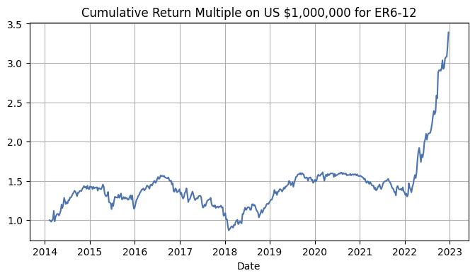

```python
position_dict[target_1[0]] = get_bt_stats(target_1_position, target_1, DV01, aum)
```

## Target 2:Canada 10Y-2Y Yield Curve

```python
target_2 = ['CA102']
target_2_features = get_features(full_data_wf.loc[:'2023'],
                                     beg, end, target_2
)

# Get data
_X, _y = lag_feature(full_data_wf.loc[:'2023'],
                      target_2_features,
                      target_2
)

# Run Logit Model
X_, y_ = filter(_X, _y, beg, end)

log_model = train_logit(X_, y_)

valid_X, valid_y = filter(_X, _y, end, end+52)

score = valid_logit(valid_X, valid_y, log_model)
print('Logit model score:', round(score,2))

# Run Random Forest Classification Model

rfc_model, rfc_score, rfc_n = train_valid_rfc(X_, y_, valid_X, valid_y)
print('Best F1 score for RFC:', round(rfc_score,2))
print('Best number of estimators:', rfc_n)

# Run SVC Model

svc_model, svc_score, svc_n = train_valid_svc(X_, y_, valid_X, valid_y)
print('Best F1 score for SVC:', round(svc_score,2))
print('Best C for SVC:', svc_n)
```

```
Logit model score: 0.4
Best F1 score for RFC: 0.37
Best number of estimators: 250
Best F1 score for SVC: 0.47
Best C for SVC: 651
```

### Walk-forward analysis

```python
target_2_wf_dict = dict() # dictionary to save scores
target_2_position = dict() # dictionary to save positions

# Get data
X, y = lag_feature(full_data_wf.loc[:'2023'],
                      target_2_features,
                      target_2
)

for idx in range(0, X.shape[0] - (52*(look_back+2))):

  _beg = idx
  _end = idx + (52*look_back)

  if idx % 13 == 0: # refresh models every quarter
    # Refresh features via updated correlations
    target_2_features = get_features(full_data_wf.loc[:'2023'],
                                     _beg, _end, target_2
    )
    # Get data
    X, y = lag_feature(full_data_wf.loc[:'2023'],
                          target_2_features,
                          target_2
    )

    # Run Logit Model
    _X, _y = filter(X, y, beg, end)

    _log_model = train_logit(_X, _y)

    _valid_X, _valid_y = filter(X, y, _end, _end+52)

    _score = valid_logit(_valid_X, _valid_y, _log_model)

    # Run Random Forest Classification Model
    _rfc_model, _rfc_score, _rfc_n = train_valid_rfc(_X, _y, _valid_X, _valid_y)

    # Run SVC Model
    _svc_model, _svc_score, _svc_n = train_valid_svc(_X, _y, _valid_X, _valid_y)

    # Save the scores indexed by ending year of training period
    target_2_wf_dict[X.index[beg]] = [round(_score,2), round(_rfc_score,2), round(_svc_score,2)]

  # Forecast
  _test_X, _test_y = filter(X, y, _end+52, _end+(52+1))

  _log_pred = _log_model.predict(_test_X)
  _rfc_pred = _rfc_model.predict(_test_X)
  _svc_pred = _svc_model.predict(_test_X)

  _mode = multimode([_log_pred[0], _rfc_pred[0], _svc_pred[0]])
  if len(_mode) > 1:
    _mode = [0]

  target_2_position[_test_X.index[0]] = _mode[0]
```

### Backtest results

```
-----------------------------------------------------------------
Backtest Results for CA102
Annualized Mean Return %: 16.37
Annualized St Deviation %: 35.79
Sharpe Ratio assuming rf = 0: 0.46
Max Drawdown %: -72.37
Cumulative Return %: 241.6
Sortino Ratio assuming rf = 0: 0.61
Calmor Ratio 0.23
-----------------------------------------------------------------
```

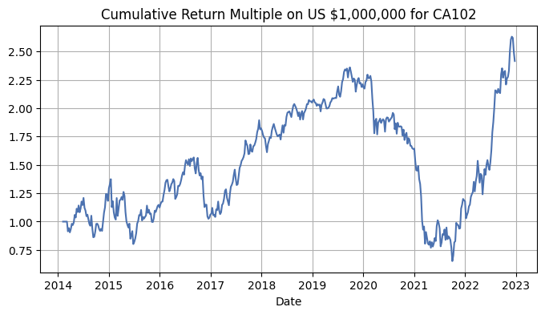

```python
position_dict[target_2[0]] = get_bt_stats(target_2_position, target_2, DV01, aum)
```

## Target 3: US 5Y-2Y Yield Curve

```python
target_3 = ['US52']
target_3_features = get_features(full_data_wf.loc[:'2023'],
                                     beg, end, target_3
)
# Get data
_X, _y = lag_feature(full_data_wf.loc[:'2023'],
                      target_3_features,
                      target_3
)

# Run Logit Model
X_, y_ = filter(_X, _y, beg, end)

log_model = train_logit(X_, y_)

valid_X, valid_y = filter(_X, _y, end, end+52)

score = valid_logit(valid_X, valid_y, log_model)
print('Logit model score:', round(score,2))

# Run Random Forest Classification Model

rfc_model, rfc_score, rfc_n = train_valid_rfc(X_, y_, valid_X, valid_y)
print('Best F1 score for RFC:', round(rfc_score,2))
print('Best number of estimators:', rfc_n)

# Run SVC Model

svc_model, svc_score, svc_n = train_valid_svc(X_, y_, valid_X, valid_y)
print('Best F1 score for SVC:', round(svc_score,2))
print('Best C for SVC:', svc_n)
```

```
Logit model score: 0.29
Best F1 score for RFC: 0.35
Best number of estimators: 150
Best F1 score for SVC: 0.32
Best C for SVC: 251
```

### Walk-forward analysis

```python
target_3_wf_dict = dict() # dictionary to save scores
target_3_position = dict() # dictionary to save positions

# Get data
X, y = lag_feature(full_data_wf.loc[:'2023'],
                      target_3_features,
                      target_3
)

for idx in range(0, X.shape[0] - (52*(look_back+2))):

  _beg = idx
  _end = idx + (52*look_back)

  if idx % 13 == 0: # refresh models every quarter
    # Refresh features via updated correlations
    target_3_features = get_features(full_data_wf.loc[:'2023'],
                                     _beg, _end, target_3
    )
    # Get data
    X, y = lag_feature(full_data_wf.loc[:'2023'],
                          target_3_features,
                          target_3
    )

    # Run Logit Model
    _X, _y = filter(X, y, beg, end)

    _log_model = train_logit(_X, _y)

    _valid_X, _valid_y = filter(X, y, _end, _end+52)

    _score = valid_logit(_valid_X, _valid_y, _log_model)

    # Run Random Forest Classification Model
    _rfc_model, _rfc_score, _rfc_n = train_valid_rfc(_X, _y, _valid_X, _valid_y)

    # Run SVC Model
    _svc_model, _svc_score, _svc_n = train_valid_svc(_X, _y, _valid_X, _valid_y)

    # Save the scores indexed by ending year of training period
    target_3_wf_dict[X.index[beg]] = [round(_score,2), round(_rfc_score,2), round(_svc_score,2)]

  # Forecast
  _test_X, _test_y = filter(X, y, _end+52, _end+(52+1)
  )

  _log_pred = _log_model.predict(_test_X)
  _rfc_pred = _rfc_model.predict(_test_X)
  _svc_pred = _svc_model.predict(_test_X)


  _mode = multimode([_log_pred[0], _rfc_pred[0], _svc_pred[0]])
  if len(_mode) > 1:
    _mode = [0]

  target_3_position[_test_X.index[0]] = _mode[0]
```

### Backtest results

```
-----------------------------------------------------------------
Backtest Results for US52
Annualized Mean Return %: 11.97
Annualized St Deviation %: 20.92
Sharpe Ratio assuming rf = 0: 0.57
Max Drawdown %: -37.48
Cumulative Return %: 238.96
Sortino Ratio assuming rf = 0: 0.86
Calmor Ratio 0.32
-----------------------------------------------------------------
```

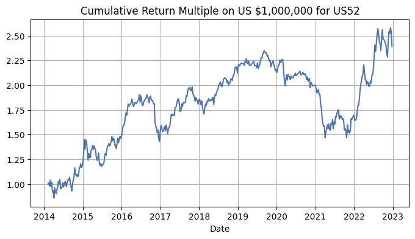

```python
position_dict[target_3[0]] = get_bt_stats(target_3_position, target_3, DV01, aum)
```

## Target 4: US 30Y-2Y Yield Curve

```python
target_4 = ['US302']
target_4_features = get_features(full_data_wf.loc[:'2023'],
                                     beg, end, target_4
)
# Get data
_X, _y = lag_feature(full_data_wf.loc[:'2023'],
                      target_4_features,
                      target_4
)

# Run Logit Model
X_, y_ = filter(_X, _y, beg, end)

log_model = train_logit(X_, y_)

valid_X, valid_y = filter(_X, _y, end, end+52)

score = valid_logit(valid_X, valid_y, log_model)
print('Logit model score:', round(score,2))

# Run Random Forest Classification Model

rfc_model, rfc_score, rfc_n = train_valid_rfc(X_, y_, valid_X, valid_y)
print('Best F1 score for RFC:', round(rfc_score,2))
print('Best number of estimators:', rfc_n)

# Run SVC Model

svc_model, svc_score, svc_n = train_valid_svc(X_, y_, valid_X, valid_y)
print('Best F1 score for SVC:', round(svc_score,2))
print('Best C for SVC:', svc_n)
```

```
Logit model score: 0.38
Best F1 score for RFC: 0.4
Best number of estimators: 250
Best F1 score for SVC: 0.35
Best C for SVC: 451
```

### Walk-forward analysis

```python
target_4_wf_dict = dict() # dictionary to save scores
target_4_position = dict() # dictionary to save positions

# Get data
X, y = lag_feature(full_data_wf.loc[:'2023'],
                      target_4_features,
                      target_4
)

for idx in range(0, X.shape[0] - (52*(look_back+2))):

  _beg = idx
  _end = idx + (52*look_back)

  if idx % 13 == 0: # refresh models every quarter
    # Refresh features via updated correlations
    target_4_features = get_features(full_data_wf.loc[:'2023'],
                                     _beg, _end, target_4
    )
    # Get data
    X, y = lag_feature(full_data_wf.loc[:'2023'],
                          target_4_features,
                          target_4
    )

    # Run Logit Model
    _X, _y = filter(X, y, beg, end)

    _log_model = train_logit(_X, _y)

    _valid_X, _valid_y = filter(X, y, _end, _end+52)

    _score = valid_logit(_valid_X, _valid_y, _log_model)

    # Run Random Forest Classification Model
    _rfc_model, _rfc_score, _rfc_n = train_valid_rfc(_X, _y, _valid_X, _valid_y)

    # Run SVC Model
    _svc_model, _svc_score, _svc_n = train_valid_svc(_X, _y, _valid_X, _valid_y)

    # Save the scores indexed by ending year of training period
    target_4_wf_dict[X.index[beg]] = [round(_score,2), round(_rfc_score,2), round(_svc_score,2)]

  # Forecast
  _test_X, _test_y = filter(X, y, _end+52, _end+(52+1)
  )

  _log_pred = _log_model.predict(_test_X)
  _rfc_pred = _rfc_model.predict(_test_X)
  _svc_pred = _svc_model.predict(_test_X)

  _mode = multimode([_log_pred[0], _rfc_pred[0], _svc_pred[0]])
  if len(_mode) > 1:
    _mode = [0]

  target_4_position[_test_X.index[0]] = _mode[0]
```

### Backtest results

```
-----------------------------------------------------------------
Backtest Results for US302
Annualized Mean Return %: 20.07
Annualized St Deviation %: 24.2
Sharpe Ratio assuming rf = 0: 0.83
Max Drawdown %: -38.5
Cumulative Return %: 460.03
Sortino Ratio assuming rf = 0: 1.43
Calmor Ratio 0.52
-----------------------------------------------------------------
```

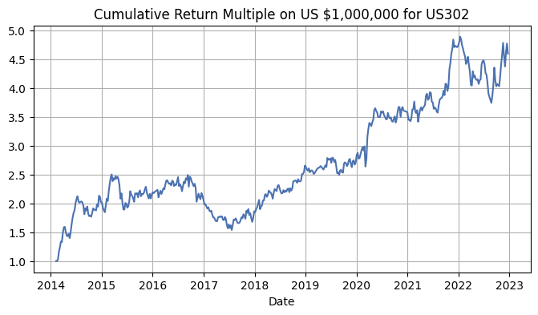

```python
position_dict[target_4[0]] = get_bt_stats(target_4_position, target_4, DV01, aum)
```

## Target 5: US SOFR 4th contract - 8th contract (2Y-1Y Yield Curve)

```python
target_5 = ['SFR4-8']
target_5_features = get_features(full_data_wf.loc[:'2023'],
                                     beg, end, target_5
)

# Get data
_X, _y = lag_feature(full_data_wf.loc[:'2023'],
                      target_5_features,
                      target_5
)

# Run Logit Model
X_, y_ = filter(_X, _y, beg, end)

log_model = train_logit(X_, y_)

valid_X, valid_y = filter(_X, _y, end, end+52)

score = valid_logit(valid_X, valid_y, log_model)
print('Logit model score:', round(score,2))

# Run Random Forest Classification Model

rfc_model, rfc_score, rfc_n = train_valid_rfc(X_, y_, valid_X, valid_y)
print('Best F1 score for RFC:', round(rfc_score,2))
print('Best number of estimators:', rfc_n)

# Run SVC Model

svc_model, svc_score, svc_n = train_valid_svc(X_, y_, valid_X, valid_y)
print('Best F1 score for SVC:', round(svc_score,2))
print('Best C for SVC:', svc_n)
```

```
Logit model score: 0.42
Best F1 score for RFC: 0.42
Best number of estimators: 100
Best F1 score for SVC: 0.46
Best C for SVC: 151
```

### Walk-forward analysis

```python
target_5_wf_dict = dict() # dictionary to save scores
target_5_position = dict() # dictionary to save positions

# Get data
X, y = lag_feature(full_data_wf.loc[:'2023'],
                      target_5_features,
                      target_5
)

for idx in range(0, X.shape[0] - (52*(look_back+2))):

  _beg = idx
  _end = idx + (52*look_back)

  if idx % 13 == 0: # refresh models every quarter
    # Refresh features via updated correlations
    target_5_features = get_features(full_data_wf.loc[:'2023'],
                                     _beg, _end, target_5
    )
    # Get data
    X, y = lag_feature(full_data_wf.loc[:'2023'],
                          target_5_features,
                          target_5
    )

    # Run Logit Model
    _X, _y = filter(X, y, beg, end)

    _log_model = train_logit(_X, _y)

    _valid_X, _valid_y = filter(X, y, _end, _end+52)

    _score = valid_logit(_valid_X, _valid_y, _log_model)

    # Run Random Forest Classification Model
    _rfc_model, _rfc_score, _rfc_n = train_valid_rfc(_X, _y, _valid_X, _valid_y)

    # Run SVC Model
    _svc_model, _svc_score, _svc_n = train_valid_svc(_X, _y, _valid_X, _valid_y)

    # Save the scores indexed by ending year of training period
    target_5_wf_dict[X.index[beg]] = [round(_score,2), round(_rfc_score,2), round(_svc_score,2)]

  # Forecast
  _test_X, _test_y = filter(X, y, _end+52, _end+(52+1))

  _log_pred = _log_model.predict(_test_X)
  _rfc_pred = _rfc_model.predict(_test_X)
  _svc_pred = _svc_model.predict(_test_X)

  _mode = multimode([_log_pred[0], _rfc_pred[0], _svc_pred[0]])
  if len(_mode) > 1:
    _mode = [0]

  target_5_position[_test_X.index[0]] = _mode[0]
```

### Backtest results

```
-----------------------------------------------------------------
Backtest Results for SFR4-8
Annualized Mean Return %: 19.98
Annualized St Deviation %: 38.94
Sharpe Ratio assuming rf = 0: 0.51
Max Drawdown %: -57.86
Cumulative Return %: 304.0
Sortino Ratio assuming rf = 0: 0.67
Calmor Ratio 0.35
-----------------------------------------------------------------
```

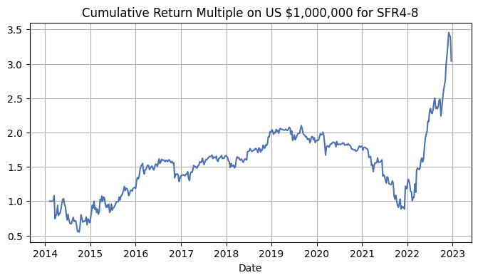

```python
position_dict[target_5[0]] = get_bt_stats(target_5_position, target_5, DV01, aum)
```

## Target 6: US 10Y-2Y Yield Curve

```python
target_6 = ['US102']
target_6_features = get_features(full_data_wf.loc[:'2023'],
                                     beg, end, target_6
)
# Get data
_X, _y = lag_feature(full_data_wf.loc[:'2023'],
                      target_6_features,
                      target_6
)

# Run Logit Model
X_, y_ = filter(_X, _y, beg, end)

log_model = train_logit(X_, y_)

valid_X, valid_y = filter(_X, _y, end, end+52)

score = valid_logit(valid_X, valid_y, log_model)
print('Logit model score:', round(score,2))

# Run Random Forest Classification Model

rfc_model, rfc_score, rfc_n = train_valid_rfc(X_, y_, valid_X, valid_y)
print('Best F1 score for RFC:', round(rfc_score,2))
print('Best number of estimators:', rfc_n)

# Run SVC Model

svc_model, svc_score, svc_n = train_valid_svc(X_, y_, valid_X, valid_y)
print('Best F1 score for SVC:', round(svc_score,2))
print('Best C for SVC:', svc_n)
```

```
Logit model score: 0.35
Best F1 score for RFC: 0.2
Best number of estimators: 250
Best F1 score for SVC: 0.34
Best C for SVC: 751
```

### Walk-forward analysis

```python
target_6_wf_dict = dict() # dictionary to save scores
target_6_position = dict() # dictionary to save positions

# Get data
X, y = lag_feature(full_data_wf.loc[:'2023'],
                      target_6_features,
                      target_6
)

for idx in range(0, X.shape[0] - (52*(look_back+2))):

  _beg = idx
  _end = idx + (52*look_back)

  if idx % 13 == 0: # refresh models every quarter
    # Refresh features via updated correlations
    target_6_features = get_features(full_data_wf.loc[:'2023'],
                                     _beg, _end, target_6
    )
    # Get data
    X, y = lag_feature(full_data_wf.loc[:'2023'],
                          target_6_features,
                          target_6
    )

    # Run Logit Model
    _X, _y = filter(X, y, beg, end)

    _log_model = train_logit(_X, _y)

    _valid_X, _valid_y = filter(X, y, _end, _end+52)

    _score = valid_logit(_valid_X, _valid_y, _log_model)

    # Run Random Forest Classification Model
    _rfc_model, _rfc_score, _rfc_n = train_valid_rfc(_X, _y, _valid_X, _valid_y)

    # Run SVC Model
    _svc_model, _svc_score, _svc_n = train_valid_svc(_X, _y, _valid_X, _valid_y)

    # Save the scores indexed by ending year of training period
    target_6_wf_dict[X.index[beg]] = [round(_score,2), round(_rfc_score,2), round(_svc_score,2)]

  # Forecast
  _test_X, _test_y = filter(X, y, _end+52, _end+(52+1)
  )

  _log_pred = _log_model.predict(_test_X)
  _rfc_pred = _rfc_model.predict(_test_X)
  _svc_pred = _svc_model.predict(_test_X)

  _mode = multimode([_log_pred[0], _rfc_pred[0], _svc_pred[0]])
  if len(_mode) > 1:
    _mode = [0]

  target_6_position[_test_X.index[0]] = _mode[0]
```

### Backtest results

```
-----------------------------------------------------------------
Backtest Results for US102
Annualized Mean Return %: 18.83
Annualized St Deviation %: 16.33
Sharpe Ratio assuming rf = 0: 1.15
Max Drawdown %: -24.88
Cumulative Return %: 474.32
Sortino Ratio assuming rf = 0: 2.09
Calmor Ratio 0.76
-----------------------------------------------------------------
```

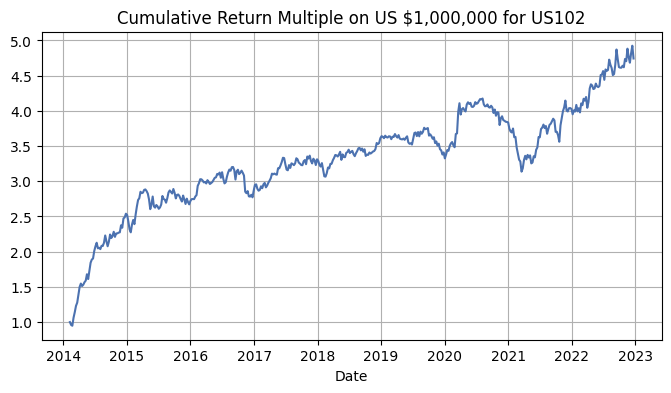

```python
position_dict[target_6[0]] = get_bt_stats(target_6_position, target_6, DV01, aum)
```

## Target 7: German 10Y-2Y Yield Curve

```python
target_7 = ['DE102']
target_7_features = get_features(full_data_wf.loc[:'2023'],
                                     beg, end, target_7
)
# Get data
_X, _y = lag_feature(full_data_wf.loc[:'2023'],
                      target_7_features,
                      target_7
)

# Run Logit Model
X_, y_ = filter(_X, _y, beg, end)

log_model = train_logit(X_, y_)

valid_X, valid_y = filter(_X, _y, end, end+52)

score = valid_logit(valid_X, valid_y, log_model)
print('Logit model score:', round(score,2))

# Run Random Forest Classification Model

rfc_model, rfc_score, rfc_n = train_valid_rfc(X_, y_, valid_X, valid_y)
print('Best F1 score for RFC:', round(rfc_score,2))
print('Best number of estimators:', rfc_n)

# Run SVC Model

svc_model, svc_score, svc_n = train_valid_svc(X_, y_, valid_X, valid_y)
print('Best F1 score for SVC:', round(svc_score,2))
print('Best C for SVC:', svc_n)
```

```
Logit model score: 0.37
Best F1 score for RFC: 0.29
Best number of estimators: 100
Best F1 score for SVC: 0.34
Best C for SVC: 301
```

### Walk-forward analysis

```python
target_7_wf_dict = dict() # dictionary to save scores
target_7_position = dict() # dictionary to save positions

# Get data
X, y = lag_feature(full_data_wf.loc[:'2023'],
                      target_7_features,
                      target_7
)

for idx in range(0, X.shape[0] - (52*(look_back+2))):

  _beg = idx
  _end = idx + (52*look_back)

  if idx % 13 == 0: # refresh models every quarter
    # Refresh features via updated correlations
    target_7_features = get_features(full_data_wf.loc[:'2023'],
                                     _beg, _end, target_7
    )

    # Get data
    X, y = lag_feature(full_data_wf.loc[:'2023'],
                          target_7_features,
                          target_7
    )

    # Run Logit Model
    _X, _y = filter(X, y, beg, end)

    _log_model = train_logit(_X, _y)

    _valid_X, _valid_y = filter(X, y, _end, _end+52)

    _score = valid_logit(_valid_X, _valid_y, _log_model)

    # Run Random Forest Classification Model
    _rfc_model, _rfc_score, _rfc_n = train_valid_rfc(_X, _y, _valid_X, _valid_y)

    # Run SVC Model
    _svc_model, _svc_score, _svc_n = train_valid_svc(_X, _y, _valid_X, _valid_y)

    # Save the scores indexed by ending year of training period
    target_7_wf_dict[X.index[beg]] = [round(_score,2), round(_rfc_score,2), round(_svc_score,2)]

  # Forecast
  _test_X, _test_y = filter(X, y, _end+52, _end+(52+1)
  )

  _log_pred = _log_model.predict(_test_X)
  _rfc_pred = _rfc_model.predict(_test_X)
  _svc_pred = _svc_model.predict(_test_X)

  _mode = multimode([_log_pred[0], _rfc_pred[0], _svc_pred[0]])
  if len(_mode) > 1:
    _mode = [0]

  target_7_position[_test_X.index[0]] = _mode[0]
```

### Backtest results

```
-----------------------------------------------------------------
Backtest Results for DE102
Annualized Mean Return %: 19.16
Annualized St Deviation %: 16.98
Sharpe Ratio assuming rf = 0: 1.13
Max Drawdown %: -24.96
Cumulative Return %: 483.8
Sortino Ratio assuming rf = 0: 1.76
Calmor Ratio 0.77
-----------------------------------------------------------------
```

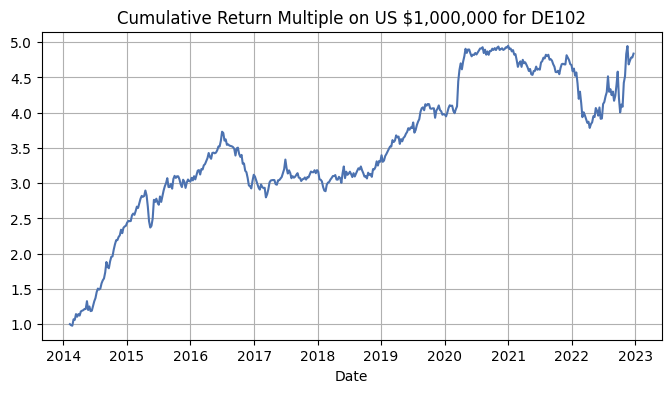

```python
position_dict[target_7[0]] = get_bt_stats(target_7_position, target_7, DV01, aum)
```

## Target 8: German 5Y-2Y Yield Curve

```python
target_8 = ['DE52']
target_8_features = get_features(full_data_wf.loc[:'2023'],
                                     beg, end, target_8
)

# Get data
_X, _y = lag_feature(full_data_wf.loc[:'2023'],
                      target_8_features,
                      target_8
)

# Run Logit Model
X_, y_ = filter(_X, _y, beg, end)

log_model = train_logit(X_, y_)

valid_X, valid_y = filter(_X, _y, end, end+52)

score = valid_logit(valid_X, valid_y, log_model)
print('Logit model score:', round(score,2))

# Run Random Forest Classification Model

rfc_model, rfc_score, rfc_n = train_valid_rfc(X_, y_, valid_X, valid_y)
print('Best F1 score for RFC:', round(rfc_score,2))
print('Best number of estimators:', rfc_n)

# Run SVC Model

svc_model, svc_score, svc_n = train_valid_svc(X_, y_, valid_X, valid_y)
print('Best F1 score for SVC:', round(svc_score,2))
print('Best C for SVC:', svc_n)
```

```
Logit model score: 0.37
Best F1 score for RFC: 0.26
Best number of estimators: 150
Best F1 score for SVC: 0.35
Best C for SVC: 1
```

### Walk-forward analysis

```python
target_8_wf_dict = dict() # dictionary to save scores
target_8_position = dict() # dictionary to save positions

# Get data
X, y = lag_feature(full_data_wf.loc[:'2023'],
                      target_8_features,
                      target_8
)

for idx in range(0, X.shape[0] - (52*(look_back+2))):

  _beg = idx
  _end = idx + (52*look_back)

  if idx % 13 == 0: # refresh models every quarter
    # Refresh features via updated correlations
    target_8_features = get_features(full_data_wf.loc[:'2023'],
                                     _beg, _end, target_8
    )

    # Get data
    X, y = lag_feature(full_data_wf.loc[:'2023'],
                          target_8_features,
                          target_8
    )

    # Run Logit Model
    _X, _y = filter(X, y, beg, end)

    _log_model = train_logit(_X, _y)

    _valid_X, _valid_y = filter(X, y, _end, _end+52)

    _score = valid_logit(_valid_X, _valid_y, _log_model)

    # Run Random Forest Classification Model
    _rfc_model, _rfc_score, _rfc_n = train_valid_rfc(_X, _y, _valid_X, _valid_y)

    # Run SVC Model
    _svc_model, _svc_score, _svc_n = train_valid_svc(_X, _y, _valid_X, _valid_y)

    # Save the scores indexed by ending year of training period
    target_8_wf_dict[X.index[beg]] = [round(_score,2), round(_rfc_score,2), round(_svc_score,2)]

  # Forecast
  _test_X, _test_y = filter(X, y, _end+52, _end+(52+1)
  )

  _log_pred = _log_model.predict(_test_X)
  _rfc_pred = _rfc_model.predict(_test_X)
  _svc_pred = _svc_model.predict(_test_X)

  _mode = multimode([_log_pred[0], _rfc_pred[0], _svc_pred[0]])
  if len(_mode) > 1:
    _mode = [0]

  target_8_position[_test_X.index[0]] = _mode[0]
```

### Backtest results

```
-----------------------------------------------------------------
Backtest Results for DE52
Annualized Mean Return %: 15.16
Annualized St Deviation %: 30.91
Sharpe Ratio assuming rf = 0: 0.49
Max Drawdown %: -45.62
Cumulative Return %: 253.3
Sortino Ratio assuming rf = 0: 0.72
Calmor Ratio 0.33
-----------------------------------------------------------------
```

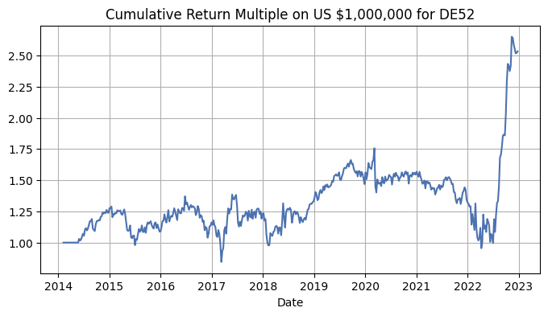

```python
position_dict[target_8[0]] = get_bt_stats(target_8_position, target_8, DV01, aum)
```

## Target 9: Italy 10Y - German 10Y

```python
def make_pca(df, beg, end):
  cds = df.fillna(method='ffill').iloc[beg : end].diff().dropna().values
  scaler = StandardScaler()
  scaled_cds = scaler.fit_transform(cds)

  pca = PCA(n_components=3)

  pc = pca.fit_transform(scaled_cds)

  # multiply PCA loadings with scaled underlying data
  scaled_cds_array = np.array(scaled_cds)
  scaled_loadings = np.dot(scaled_cds_array, pca.components_.T)

  # multiply "scaled loadings" with principal component weights, respectively
  # to create one index that combines all three principal components
  # this index had to be negated to make it comparable with underlying CDS data

  EZ_risk_index = -np.dot(scaled_loadings, pca.explained_variance_)
  EZ_risk = pd.DataFrame(EZ_risk_index.cumsum(),
                         index=df.iloc[beg : end].index[1:]
  )
  EZ_risk.columns = ['EZ Risk Index']
  return EZ_risk/100

def lag_feature_pca(df, features_df, features2, target, beg, end, _beg):
  '''
  Function takes a pandas dataframe and inserts lags of all columns.
  Returns a dataframe with all lags inserted, first differenced,
  and a target series as a categorical variable.
  '''
  df_ = df[features2 + target].iloc[beg : end].fillna(method='ffill').copy()
  pca_df = make_pca(features_df, beg, end)
  df_ = pd.concat([df_, pca_df], axis=1)


  tmp_dict = dict()
  for col in df_.columns:
    for l in range(1,5):
      tmp_col = df_[col].shift(l).copy()
      tmp_dict[col+'L'+str(l)] = tmp_col
  df_ = pd.concat([df_,
                 pd.DataFrame.from_dict(tmp_dict)],
                 axis=1
  )
  df_[target] = df_[target].shift(-1)

  df_.dropna(inplace=True)

  X = df_.diff()[1:].fillna(method='ffill').iloc[_beg:].drop(target, axis=1)
  y = df_[target].diff()[1:].fillna(method='ffill').iloc[_beg:]

  upper = 0.03
  lower = -0.03
  y = pd.DataFrame(np.where(y > upper, 1, np.where(y < lower, -1, 0)))
  return X, y
```

```python
target_9 = ['ITDE10']
target_9_features = file_dict['ez_cds'].resample('W-FRI').last().copy()

target_9_features2 = get_features(full_data_wf.loc[:'2023'],
                                     beg, end, target_9
)

# Get data
X_, y_ = lag_feature_pca(full_data_wf.loc[:'2023'],
                      target_9_features,target_9_features2,
                      target_9, beg, end, 0
)

# Run Logit Model

log_model = train_logit(X_, y_)


valid_X, valid_y = lag_feature_pca(full_data_wf.loc[:'2023'],
                      target_9_features,target_9_features2,
                      target_9, beg, end+52, end
)

#valid_X, valid_y = filter(_X, _y, end, end+52)

score = valid_logit(valid_X, valid_y, log_model)
print('Logit model score:', round(score,2))

#print(_X)
#print(_y)
```

```
Logit model score: 0.33
```

```python
target_9 = ['ITDE10']
target_9_features = file_dict['ez_cds'].resample('W-FRI').last().copy()
#target_9_features2 = feature_dict[target_9[0]]

target_9_features2 = get_features(full_data_wf.loc[:'2023'],
                                     beg, end, target_9
)

# Note that this process is slightly different given the PCA feature

# Get data
X_, y_ = lag_feature_pca(full_data_wf.loc[:'2023'],
                      target_9_features,target_9_features2,
                      target_9, beg, end, 0
)

# Run Logit Model

log_model = train_logit(X_, y_)


valid_X, valid_y  = lag_feature_pca(full_data_wf.loc[:'2023'],
                      target_9_features,target_9_features2,
                      target_9, beg, end+52, -52
)
#valid_X, valid_y = filter(X_, y_, end, end+52)

score = valid_logit(valid_X, valid_y, log_model)
print('Logit model score:', round(score,2))

# Run Random Forest Classification Model

rfc_model, rfc_score, rfc_n = train_valid_rfc(X_, y_, valid_X, valid_y)
print('Best F1 score for RFC:', round(rfc_score,2))
print('Best number of estimators:', rfc_n)

# Run SVC Model

svc_model, svc_score, svc_n = train_valid_svc(X_, y_, valid_X, valid_y)
print('Best F1 score for SVC:', round(svc_score,2))
print('Best C for SVC:', svc_n)

print()
```

```
Logit model score: 0.33
Best F1 score for RFC: 0.32
Best number of estimators: 100
Best F1 score for SVC: 0.47
Best C for SVC: 351
```

### Walk-forward analysis

```python
target_9_wf_dict = dict() # dictionary to save scores
target_9_position = dict() # dictionary to save positions

# Get data
_X, _y = lag_feature_pca(full_data_wf.loc[:'2023'],
                    target_9_features,target_9_features2,
                    target_9, 0, 0+(52*look_back), 0
)

for idx in range(0, full_data_wf.loc[:'2023'].shape[0] - (52*(look_back+2))):

  _beg = idx
  _end = idx + (52*look_back)

  if idx % 13 == 0: # refresh models every quarter
    # Refresh features via updated correlations
    target_9_features2 = get_features(full_data_wf.loc[:'2023'],
                                     _beg, _end, target_9
    )

    if 'EZ Risk Index' in target_9_features2:
      target_9_features2.remove('EZ Risk Index')

    # Get data
    _X, _y = lag_feature_pca(full_data_wf.loc[:'2023'],
                          target_9_features, target_9_features2,
                          target_9, _beg, _end, 0
    )

    # Run Logit Model

    _log_model = train_logit(_X, _y)


    _valid_X, _valid_y  = lag_feature_pca(full_data_wf.loc[:'2023'],
                      target_9_features,target_9_features2,
                      target_9, _beg, _end+52, -52
    )

    _score = valid_logit(_valid_X, _valid_y, _log_model)

    # Run Random Forest Classification Model
    _rfc_model, _rfc_score, _rfc_n = train_valid_rfc(_X, _y, _valid_X, _valid_y)

    # Run SVC Model
    _svc_model, _svc_score, _svc_n = train_valid_svc(_X, _y, _valid_X, _valid_y)

    # Save the scores indexed by ending year of training period
    target_9_wf_dict[X.index[beg]] = [round(_score,2), round(_rfc_score,2), round(_svc_score,2)]

  # Forecast
  _test_X, _test_y  = lag_feature_pca(full_data_wf.loc[:'2023'],
                      target_9_features,target_9_features2,
                      target_9, _beg, _end+52+1, -5
  )

  _log_pred = _log_model.predict(_test_X.iloc[[-1]])
  _rfc_pred = _rfc_model.predict(_test_X.iloc[[-1]])
  _svc_pred = _svc_model.predict(_test_X.iloc[[-1]])

  _mode = multimode([_log_pred[0], _rfc_pred[0], _svc_pred[0]])
  if len(_mode) > 1:
    _mode = [0]

  target_9_position[_test_X.iloc[[-1]].index[0]] = _mode[0]
```

### Backtest results

```
-----------------------------------------------------------------
Backtest Results for ITDE10
Annualized Mean Return %: 679.35
Annualized St Deviation %: 2157.53
Sharpe Ratio assuming rf = 0: 0.31
Max Drawdown %: -347.3
Cumulative Return %: 0.0
Sortino Ratio assuming rf = 0: 0.47
Calmor Ratio 1.96
-----------------------------------------------------------------
```

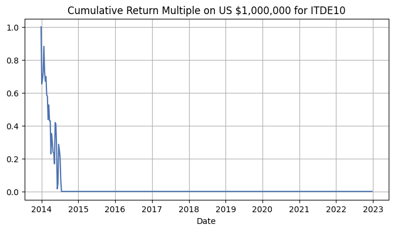

```python
position_dict[target_9[0]] = get_bt_stats(target_9_position, target_9, DV01, aum)
```

# Portfolio Construction

## Equal Weight

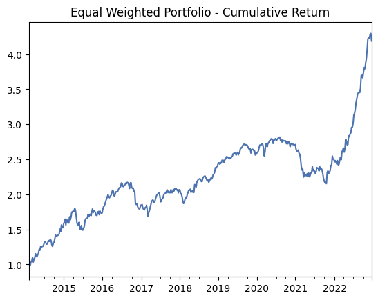

```
-----------------------------------------------------------------
Backtest Results for Equal Weighted Portfolio
Annualized Mean Return %: 17.14
Annualized St Deviation %: 14.59
Sharpe Ratio assuming rf = 0: 1.17
Max Drawdown %: -23.6
Cumulative Return %: 418.83
Sortino Ratio assuming rf = 0: 1.72
Calmor Ratio 0.73
-----------------------------------------------------------------
```

```python
strat_returns = pd.DataFrame()
for k in position_dict.keys():
  if k == 'ITDE10': # skip this strategy because backtest results were poor
    continue
  _ = pd.DataFrame.from_dict(position_dict[k][['return']])
  _.columns = [k]
  strat_returns = pd.concat([strat_returns, _], axis=1)

# create an equal-weighted portfolio
eq_w_pf = pd.DataFrame(strat_returns.mean(axis=1), columns=['return']).fillna(0)

# calculate performance statistics
eq_w_pf['neg_return'] = eq_w_pf['return'].where(eq_w_pf['return'] < 0, np.nan)
eq_w_pf['cum_return'] = np.cumprod(1 + eq_w_pf['return'].fillna(0).values)

eq_w_pf['rolling_max'] = eq_w_pf['cum_return'].cummax()
eq_w_pf['weekly_drawdown'] = eq_w_pf['cum_return']/eq_w_pf['rolling_max'] - 1.0
eq_w_pf['max_drawdown'] = eq_w_pf['weekly_drawdown'].cummin()

# repeat 0 for return if portfolio wipes out
for r in range(2, eq_w_pf.shape[0]):
  if round(eq_w_pf['cum_return'].iloc[r-1],2) <= 0.0:
    eq_w_pf['cum_return'].iloc[r-1] = 0.
    eq_w_pf['cum_return'].iloc[r] = 0.
  else:
    continue
eq_w_pf['cum_return'].plot(title='Equal Weighted Portfolio - Cumulative Return')
plt.show()

# show stats
eq_m = eq_w_pf['return'].mean() * 100 * 52
eq_s = eq_w_pf['return'].std() * 100 * np.sqrt(52)
eq_negs = eq_w_pf['neg_return'].std() * 100 * np.sqrt(52)
print('-----------------------------------------------------------------')
print('Backtest Results for Equal Weighted Portfolio')
print('Annualized Mean Return %:', round(eq_m,2))
print('Annualized St Deviation %:', round(eq_s,2))
print('Sharpe Ratio assuming rf = 0:', round(eq_m/eq_s,2))
print('Max Drawdown %:', round(eq_w_pf['max_drawdown'].min()*100,2))
print('Cumulative Return %:', round(eq_w_pf['cum_return'].iloc[-1]*100,2))
print('Sortino Ratio assuming rf = 0:', round(eq_m/eq_negs, 2))
print('Calmar Ratio', round(eq_m/(-eq_w_pf['max_drawdown'].min()*100),2))
print('-----------------------------------------------------------------')
```

## HRP

The HRP process is updated on an annual basis, i.e., annual portfolio optimization of weights. The input is the prior year's worth of weekly returns for the eight final spreads assuming a portfolio that was long all of the spreads.

```
Year: 2014
Weights:
         Weights
CA102   0.195866
DE52    0.161098
US52    0.148145
DE102   0.126547
ER6-12  0.108201
SFR4-8  0.089734
US302   0.086070
US102   0.084339
```

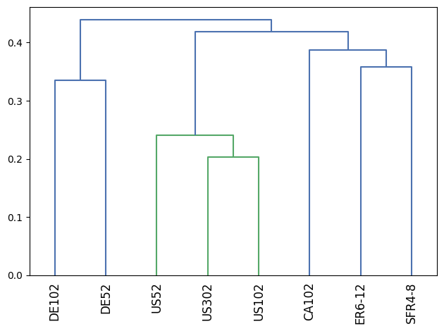

```
Year: 2022
Weights:
         Weights
ER6-12  0.330952
DE52    0.319646
DE102   0.112708
SFR4-8  0.080597
US52    0.076651
CA102   0.035904
US102   0.028938
US302   0.014604
```

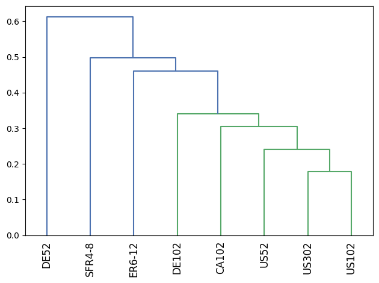

```python
hrp_wts = pd.DataFrame()
for year in range(2014,2023):

  strategies = full_data_wf[strat_returns.columns].diff().loc[str(year-1)].fillna(0) * 100 * DV01
  strategies.iloc[0] = aum
  strategies_cum_pnl = strategies.cumsum()
  strategies_rets = strategies_cum_pnl.pct_change()[1:]

  # Hierarchical risk parity:
  # Get initial weights using spread returns from prior year
  #   assuming a portfolio long all of the 8 spreads
  hrp = HRPOpt(strategies_rets)
  weights = hrp.optimize()
  hrp.portfolio_performance(verbose=False) # minimize printouts
  hrp_wts = pd.concat([hrp_wts,
                       pd.DataFrame.from_dict(weights, orient='index').T], axis=0)

  # show how dendrogram changes from beginning to end
  if year in [2014, 2022]:
    print('Year:',year)
    print('Weights:')
    print(pd.DataFrame.from_dict(weights,
                                 orient='index',
                                 columns=['Weights']).sort_values(by='Weights',
                                                          ascending=False)
    )
    plotting.plot_dendrogram(hrp)  # to plot dendrogram
    plt.show()

hrp_wts.set_index([pd.date_range(start=strat_returns.index[0],
                                 end='2023',periods=9)], inplace=True
)
```

```python
# convert HRP weights from annual to Week at Friday frequency
hrp_wts_wf = hrp_wts.resample('W-FRI').last().fillna(method='ffill')
hrp_wts_wf.head()
```

|  | CA102 | DE102 | DE52 | ER6-12 | SFR4-8 | US102 | US302 | US52 |
| --- | --- | --- | --- | --- | --- | --- | --- | --- |
| 2014-02-07 | 0.195866 | 0.126547 | 0.161098 | 0.108201 | 0.089734 | 0.084339 | 0.08607 | 0.148145 |
| 2014-02-14 | 0.195866 | 0.126547 | 0.161098 | 0.108201 | 0.089734 | 0.084339 | 0.08607 | 0.148145 |
| 2014-02-21 | 0.195866 | 0.126547 | 0.161098 | 0.108201 | 0.089734 | 0.084339 | 0.08607 | 0.148145 |
| 2014-02-28 | 0.195866 | 0.126547 | 0.161098 | 0.108201 | 0.089734 | 0.084339 | 0.08607 | 0.148145 |
| 2014-03-07 | 0.195866 | 0.126547 | 0.161098 | 0.108201 | 0.089734 | 0.084339 | 0.08607 | 0.148145 |

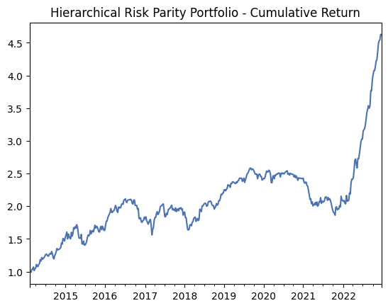

```
-----------------------------------------------------------------
Backtest Results for Hierarchical Risk Parity Portfolio
Annualized Mean Return %: 18.67
Annualized St Deviation %: 17.24
Sharpe Ratio assuming rf = 0: 1.08
Max Drawdown %: -33.9
Cumulative Return %: 462.22
Sortino Ratio assuming rf = 0: 1.58
Calmor Ratio 0.55
-----------------------------------------------------------------
```

```python
# create HRP-optimized portfolio
hrp_pf = hrp_wts_wf[strat_returns.columns].loc[strat_returns.index].multiply(strat_returns).sum(axis=1)
hrp_pf = pd.DataFrame(hrp_pf, columns=['return'])

# calculate performance statistics
hrp_pf['neg_return'] = hrp_pf['return'].where(hrp_pf['return'] < 0, np.nan)
hrp_pf['cum_return'] = np.cumprod(1 + hrp_pf['return'].fillna(0).values)

hrp_pf['rolling_max'] = hrp_pf['cum_return'].cummax()
hrp_pf['weekly_drawdown'] = hrp_pf['cum_return']/eq_w_pf['rolling_max'] - 1.0
hrp_pf['max_drawdown'] = hrp_pf['weekly_drawdown'].cummin()

# repeat 0 for return if portfolio wipes out
for r in range(2, hrp_pf.shape[0]):
  if round(hrp_pf['cum_return'].iloc[r-1],2) <= 0.0:
    hrp_pf['cum_return'].iloc[r-1] = 0.
    hrp_pf['cum_return'].iloc[r] = 0.
  else:
    continue
hrp_pf['cum_return'].plot(title='Hierarchical Risk Parity Portfolio - Cumulative Return')
plt.show()

# show stats
hrp_m = hrp_pf['return'].mean() * 100 * 52
hrp_s = hrp_pf['return'].std() * 100 * np.sqrt(52)
hrp_negs = hrp_pf['neg_return'].std() * 100 * np.sqrt(52)
print('-----------------------------------------------------------------')
print('Backtest Results for Hierarchical Risk Parity Portfolio')
print('Annualized Mean Return %:', round(hrp_m,2))
print('Annualized St Deviation %:', round(hrp_s,2))
print('Sharpe Ratio assuming rf = 0:', round(hrp_m/hrp_s,2))
print('Max Drawdown %:', round(hrp_pf['max_drawdown'].min()*100,2))
print('Cumulative Return %:', round(hrp_pf['cum_return'].iloc[-1]*100,2))
print('Sortino Ratio assuming rf = 0:', round(hrp_m/hrp_negs, 2))
print('Calmor Ratio', round(hrp_m/(-hrp_pf['max_drawdown'].min()*100),2))
print('-----------------------------------------------------------------')
```